# CAMPANHAS AGOSTO 2022

22 setembro, 2022

### TOTAL DE BONIFICAÇÕES EM AGOSTO 2022: 53.427

#### TOTAL DE BONIFICAÇÕES EM JULHO 2022: 52.525

Esse documento é uma análise visual da atividade de campanhas com bonificação em cartões Alelo.

As bonificações de AGOSTO tiveram um aumento de 1.72% em relação ao mês anterior e uma queda de -21,46% em relação ao mesmo mês do ano passado. As bonificações Insigne continuam com a maior proporção.

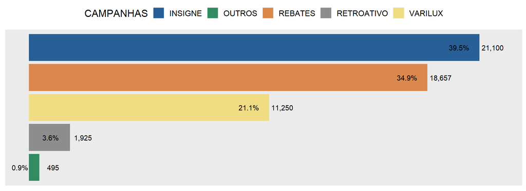

As bonificações Insigne cresceram em Agosto 6% em relação ao mês anterior .

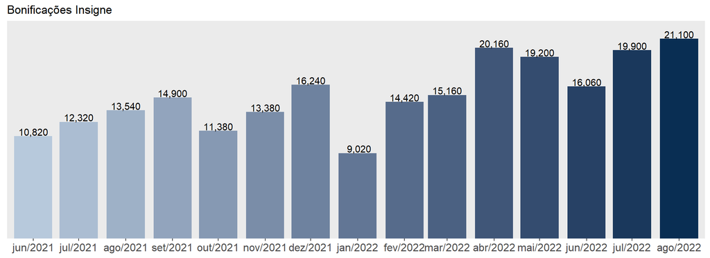

Vendas Insigne cresceram 22,25% em Agosto em relação ao mês anterior.

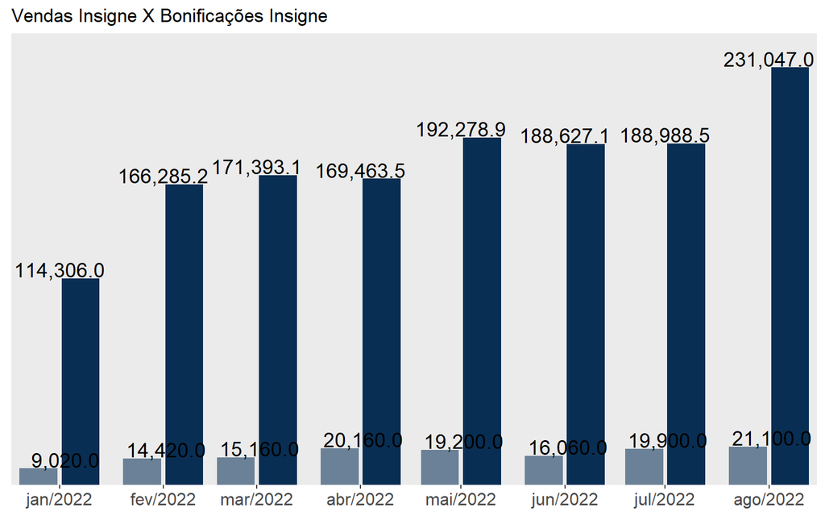

O crescimento em vendas Insigne foi maior comparado com as bonificações Insigne: 34.67% dos clientes não possuem campanha.

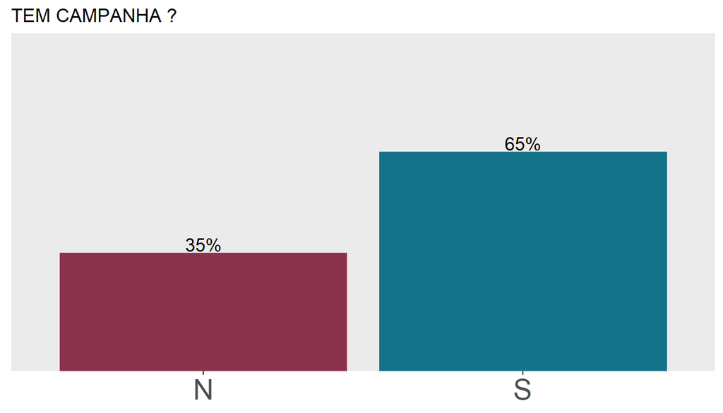

As bonificações em rebates cresceram 1,26% em Agosto comparado com o mês anterior. Em comparação, o faturamento conjunto desses 3 clientes caiu -0,7% mas apenas a Vital teve resultado negativo de -19%.

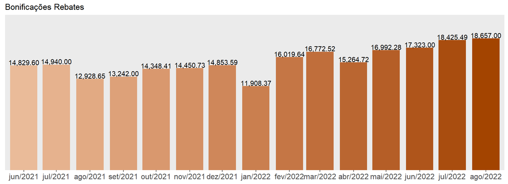

As bonificações em Varilux cresceram 106% em Agosto em comparação com o mês anterior. A bonificação mais expressiva foi a Itaçu 5k.

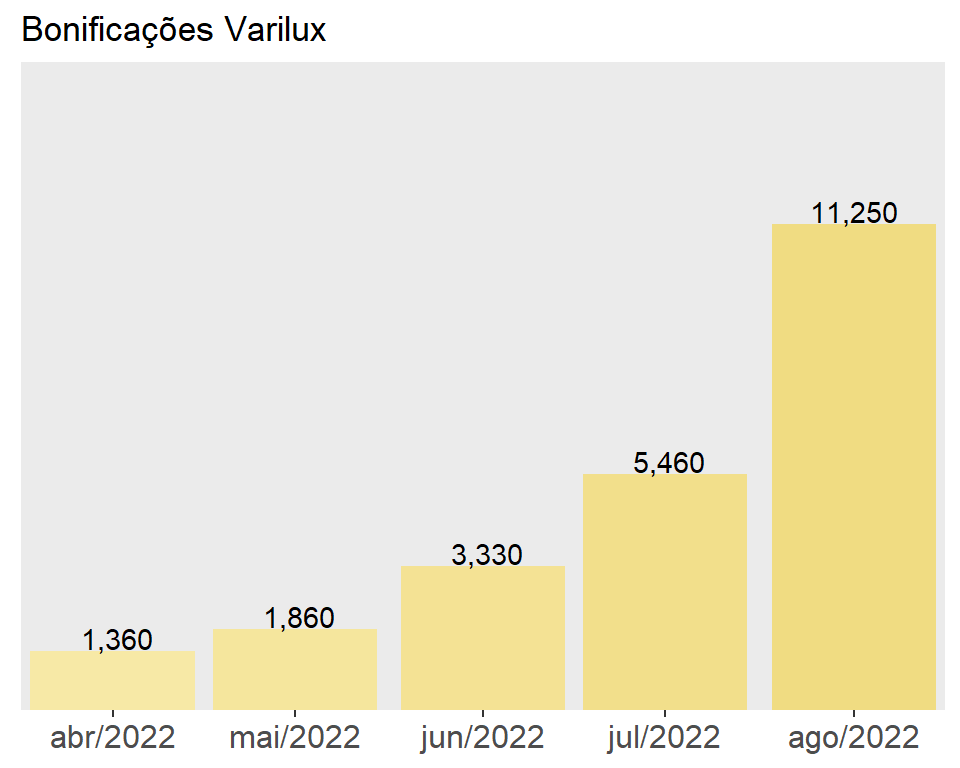

Outras campanhas não tiveram resultado significativo. A recomendação é que sejam encerradas.

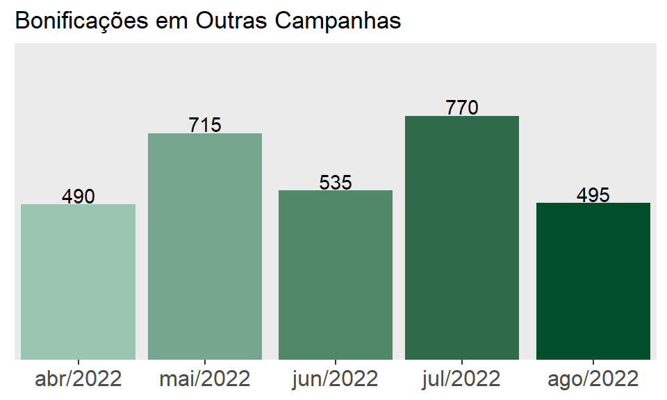

Apenas 1 pagamento retroativo foi pago este mês para a Ótica Luna (654) do Setor 2

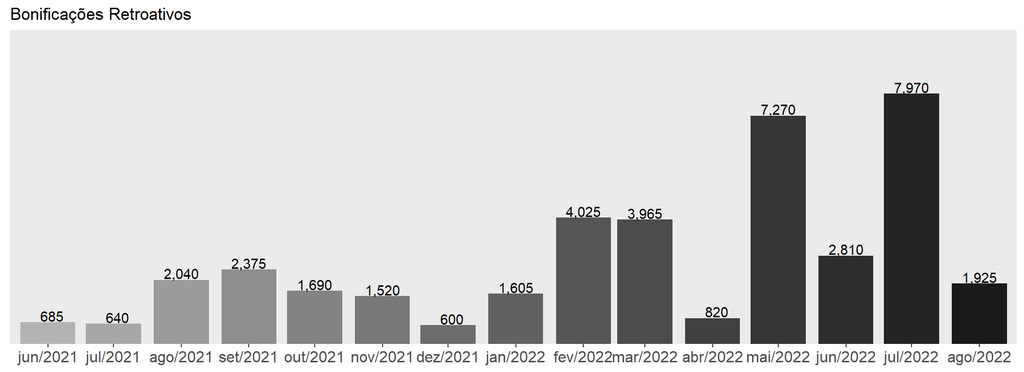